Skip to release details

Cassy v3.93.0Release report · Published 31 October 2026 · 2:24 PM ET

# Dismissals stick everywhere, idle reads as idle and Usage opens and closes.

4 changes shipped across 2 areas; Commander has 3.

One dot, one shipped change. No GitHub issues are counted in this report's fixes ledger.

See every change ↓

## Release at a glance

01 / 06

**What shipped, by area**

One dot is one Fixed entry in the v3.93.0 CHANGELOG. Dots count changes, not their size or importance.

| Area | Changes | What changed |
| --- | --- | --- |
| Commander | 3 | Dismissed sessions stay dismissed; Live idle supervisors stay green; Claude Usage opens and closes |
| Tasks | 1 | Replacement workers can deliver inherited tasks |
| Total | 4 | 2 areas |

Source: CHANGELOG `CHANGELOG.md`, release-notes draft `docs/release-notes/2026-10-31-v3.93.0-slack.md`, GitHub `Richards-LLC/cassy` release v3.93.0; retrieved 31 October 2026 · 2:28 PM ET. Product-area assignments are editorial; the release and titles are preserved.

4Changes shipped

4 fixed; tests, docs and known limits not counted

19m 46sRelease PR open to merged

PR #1443 opened 2:01 PM ET, merged 2:21 PM ET; one pass through the merge queue

2m 59sMain to published

20-minute target; 17m 1s under

3m 11sQueue green to published

20-minute budget; 16m 49s under

Changes and GitHub issues are counted separately. A change is one titled entry in the v3.93.0 CHANGELOG section; all four are fixes. Commander groups dismissals, the idle mark and Usage; Tasks holds the takeover of a gone worker's task. Empty areas are omitted, and the generator's stable area order is retained. These editorial assignments replace keyword matching. A GitHub issue counts when release PR #1443 or the CHANGELOG section references it and it closed between the PR opening (2:01 PM ET) and 15 minutes after its merge (2:36 PM ET). Issues are closed by hand shortly after the merge, so a report run inside that window waits for referenced issues that are still open. No GitHub issues are counted in this report's fixes ledger. No release stage was blocked, there were no manual interventions, and the merge queue took the release on its first entry with no ejection. Not measured for this release: request to published, cut to published, per-stage times and lesson recurrence.

The release PR opened at 2:01 PM ET and merged at 2:21 PM ET, 19 minutes 46 seconds later, after one merge-queue run went green at 2:21 PM ET. Publication then took 2 minutes 59 seconds from main, well inside the 20-minute target. The prior report, v3.90.0, took 3 hours 39 minutes from release commit to main after two queue ejections, and 13 minutes 49 seconds from main to published.

## What you can do now

02 / 06

01

### A tidier Commander

#### Dismissed sessions stay dismissed

WasAn ended session you dismissed came back after a live update or a reload, and dismissing it on one device never reached your others.

NowDismiss and Clear ended are saved on the machine itself, so the session stays hidden through updates, reloads and every browser you have paired. A new session with the same name still shows up once.

#### Idle no longer looks offline

WasA supervisor that was running but quiet showed the same gray dot as one that was offline.

NowWorking is solid green, idle is a hollow green ring, and only offline is gray. Each dot names its state when you hover or use a screen reader, and high-contrast mode tells them apart by shape. Team's Waiting and Offline labels follow the same colors. The captures show the same live, idle Claude supervisor on 3.92.0 and on this release.

[figure not shown]

Before

[figure not shown]

After

02

### Commands that finish

#### Usage works on Claude again

WasSending Usage to an idle Claude supervisor from Commander hung for about 90 seconds, showed no Close button, and blocked the next Usage until the screen was cleared.

NowUsage opens within a second with a working Close, and later commands and messages go through. The captures send Usage to the same idle Claude 2.1.312 supervisor on 3.92.0 and on this release.

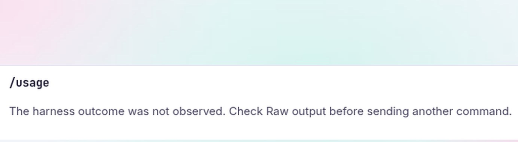

Before

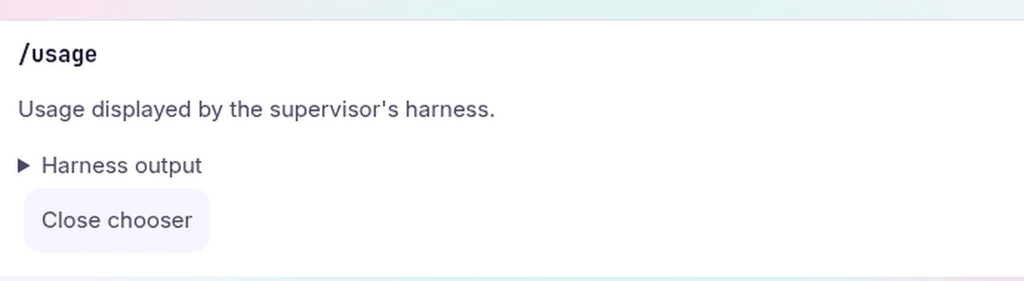

After

03

### Smoother delivery

#### Inherited work can be delivered

WasWhen a worker went away mid-task, the replacement's finished work could not be merged.

NowA supervisor can approve the replacement's own clean branch, and the work merges and closes normally while the hand-over stays on record.

## Under the hood

03 / 06

01

### Commander and hub

#### Durable dismissals

WasDismissals lived only in each browser's localStorage, keyed by session plus end time.

NowThe hub writes an atomic marker per dismissed session in its own folder, keyed by a hash of session name and start time. `GET /v1/sessions` returns `dismissed=true`, and dismissing a live or stale generation returns 409.

#### Status marks

WasLive-idle and offline supervisors computed the same gray mark.

NowWorking, Idle and Offline each have one DESIGN.md rule and matching CSS. Each mark carries `role="img"` with a state label, forced colors distinguish Idle (square) from Offline (round), and Team's Waiting and Offline pills have explicit styles.

#### Claude Usage observation

WasThe daemon confirmed `/usage` only when the screen said "Current session", which Claude 2.1.312 no longer prints, so receipts went unconfirmed at 90 s and blocked later commands. 3.91.1 failed the same way.

NowObservation matches the Usage view Claude prints today, and an uncertain receipt keeps a Close control so the native view can be dismissed before the next command. A regression test is built from the real captured screen.

02

### Factory

#### Takeover of a gone worker's task

WasAfter a worker was gone, a replacement's delivery could not be merged: `rebind_branch` refused because the assignee differed from the recorded start, and `worktree_merge` then refused the unresolved source.

Now`rebind_branch` accepts the current assignee when it is a live registered worker in the supervisor's session, holds no conflicting lease and has its own clean task branch in the same repository. The old owner, branch and anchor stay in the audit. The route is documented in CONTRIBUTING.

## Fixes ledger

04 / 06

GitHub issues closed with this release · 0

| Issue | Title | Closed | Area |
| --- | --- | --- | --- |

No GitHub issues are counted in this report's fixes ledger.

## Install

05 / 06

```
cas update --yes --version 3.93.0
```

Release assets

| Asset | Digest | Size |
| --- | --- | --- |
| cas-aarch64-apple-darwin.tar.gz | sha256:9d01e7dc9a1ff46787223d769450fdf97399e28828168e938696589a8379d7ff | 38679817 |
| cas-x86_64-unknown-linux-gnu.tar.gz | sha256:c2a644f7e19cf7f2dc2ebbedd4baa12ab4b5e3a9e517e51ad8546bb7057ea1eb | 43618223 |
| hub-deployment.json | sha256:5f7fe7ef0358100c50b2d549dc3d98a0d943ff8077f0006cfa50a2285c52495a | 643 |

## Evidence and scope

06 / 06

Source: CHANGELOG `CHANGELOG.md`, release-notes draft `docs/release-notes/2026-10-31-v3.93.0-slack.md`, GitHub `Richards-LLC/cassy` release v3.93.0; retrieved 31 October 2026 · 2:28 PM ET.

Area groupings are editorial (see the counting note); every CHANGELOG title is preserved.

Release PR: https://github.com/Richards-LLC/cassy/pull/1443 (merged 31 October 2026 · 2:21 PM ET).

GitHub release: https://github.com/Richards-LLC/cassy/releases/tag/v3.93.0 (published 31 October 2026 · 2:24 PM ET; tag v3.93.0 at 8df9bd4acab5f6bcc3ddcba876b93ae4eb73090b; Release run 41229004274).

Release commit: `8491deba6` (`release: v3.93.0`), committed 31 October 2026 · 2:01:31 PM ET.

Release receipt: the standalone `release-latency.receipt`, kept with this report's proof under the Cassy artifacts root. Before and after captures: Usage before is the installed 3.92.0 (web 5dbdc643) with Claude 2.1.312, captured during the Usage fix's own QA; after is the round 16 batch QA run of the release candidate (web bd8817ea) on a real hub with the same Claude version. The report shows crops of those two 1280×800 screenshots: the Usage receipt above the composer (2×, JPEG) and the supervisor row (2×). Dismissals have no before capture of the same surface, so no figure is shown for them.

### Pipeline latency

Command: `scripts/release-latency-receipt.sh v3.93.0 --budget-seconds 1200 --run-dir <task-proof>/latency`. Merge-queue green (CI run 41227463091) at 2:21:08 PM ET to publication at 2:24:19 PM ET is 191 seconds (3m 11s), inside the 1,200-second budget. Main landed at 2:21:20 PM ET, so main to published is 179 seconds (2m 59s). Release PR #1443 opened at 2:01:34 PM ET and merged at 2:21:20 PM ET: 1,186 seconds (19m 46s). The receipt records no per-stage seconds. Neither value stands in for another.

No source warnings.